# 第3回 欠測値への対応や標準化など前処理の実行

## 変えてみる：評価を関数に

4節 ⑤ 評価を関数に●●○○

```python
def grade(rate):           # 欠測率 rate で2つの補完を評価
    practice = make_missing(full, 'ベッド数', rate)
    miss = practice['ベッド数'].isna()
    avg = practice['ベッド数'].mean()
    by_mean = practice['ベッド数'].fillna(avg)
    ok = practice[practice['ベッド数'].notna()]
    m_bed = LinearRegression().fit(ok[['定員']], ok['ベッド数'])
    practice['予測値'] = m_bed.predict(practice[['定員']])
    by_reg = practice['ベッド数'].fillna(practice['予測値'])
    print('欠測率', round(miss.mean() * 100, 1), '%',
          ' 補完に使った平均', round(avg, 2))
    print(' 平均', round(np.abs(by_mean - truth)[miss].mean(), 2),
          ' 相関', round(full['定員'].corr(by_mean), 3))
    print(' 回帰', round(np.abs(by_reg - truth)[miss].mean(), 2),
          ' 相関', round(full['定員'].corr(by_reg), 3))

grade(0.2)
```

## セルを並べただけ

4節 ⑤ 評価を関数に●●●○

- 欠測率を変えて、何度も評価したい。だから関数にする
- 中身は、欠測を作る・平均値補完する・回帰補完するのセルを、字下げして並べただけ
- 変えたい`rate`だけを引数にする

## grade(0.2)はお手本と同じ

4節 ⑤ 評価を関数に●●●●

```
欠測率 22.8 %  補完に使った平均 3.27
 平均 1.63  相関 0.762
 回帰 0.58  相関 0.863
```

- MAE1.63台と0.58台。お手本と同じ数が出れば、正しくまとまっている

## 外のmissは書き換わる？

4節 ⑥ 中の名前●○○○○

- `grade`の中で、`practice`や`miss`という名前を作った
- 外にも、4節のお手本で作った同じ名前がある（`miss`は4,631件）

## 確かめる：同じ名前を中で作る

4節 ⑥ 中の名前●●○○○

```python
def count_missing(df):          # 表のベッド数の欠測を数える
    miss = df['ベッド数'].isna()
    return miss.sum()

print(count_missing(tr))       # 中の miss：訓練全体の欠測
print(miss.sum())              # 外の miss：4節の練習用
```

## 外のmissは4,631件のまま

4節 ⑥ 中の名前●●●○○

```
838
4631
```

- 関数の中の`miss`は、訓練全体の838件を数えた
- 外の`miss`は、4,631件のまま

## 名前は関数の中だけのもの

4節 ⑥ 中の名前●●●●○

- 関数の中で作った名前は、その関数の中だけで使われ、終わると消える
- だから途中の名前が、外の同じ名前とぶつからない
- 外の`practice`や`miss`を、うっかり書き換えずに済む

## 外の名前は読める

4節 ⑥ 中の名前●●●●●

- `grade`の中の`full`と`truth`は、外で作った名前
- 関数の中から、外の名前を読むことはできる
- ただ、何を使っているかが見えにくい。変えたいものは引数にする

## TODO②：欠測率を変える

4節 ⑦ 欠測を増やす●○○○

```python
# TODO: grade を rate=0.05 と rate=0.4 で呼ぶ
# ヒント: grade(0.05) のように、かっこの中に数を書く
...
```

- 引数を変えて呼ぶだけで、欠測率を変えてやり直せる

## やってみよう：4節とTODO②

4節 ⑦ 欠測を増やす●●○○

- 4節のお手本のセルを実行する
- TODO②：`rate`を0.05と0.4に変えて、平均値補完と回帰補完のMAE・相関を比べる

動画の人は、ここで一時停止。

## 答え合わせ：TODO②

4節 ⑦ 欠測を増やす●●●○

| rate | 欠測の割合(%) | 補完に使った平均 | 平均 MAE | 平均 相関 | 回帰 MAE | 回帰 相関 |
| --- | --- | --- | --- | --- | --- | --- |
| 0.05 | 5.8 | 3.10 | 1.51 | 0.828 | 0.58 | 0.852 |
| 0.20 | 22.8 | 3.27 | 1.63 | 0.762 | 0.58 | 0.863 |
| 0.40 | 45.5 | 3.70 | 1.90 | 0.650 | 0.59 | 0.882 |

## 欠測が増えるほど崩れる

4節 ⑦ 欠測を増やす●●●●

| rate | 欠測の割合(%) | 補完に使った平均 | 平均 MAE | 平均 相関 | 回帰 MAE | 回帰 相関 |
| --- | --- | --- | --- | --- | --- | --- |
| 0.05 | 5.8 | 3.10 | 1.51 | 0.828 | 0.58 | 0.852 |
| 0.20 | 22.8 | 3.27 | 1.63 | 0.762 | 0.58 | 0.863 |
| 0.40 | 45.5 | 3.70 | 1.90 | 0.650 | 0.59 | 0.882 |

- 平均値補完すると、MAEは1.51→1.90台、相関は0.828→0.650
- 回帰補完のMAEは、欠測率によらず0.58台前後のまま

## なぜ平均が大きくなる？

4節 ⑧ 平均がずれる●○○○○

- 欠測を増やすと、補完に使う平均が3.10→3.27→3.70台と大きくなる
- 全部の部屋の真の平均と比べると、平均そのものが、ずれていく

## 確かめる：3つの平均

4節 ⑧ 平均がずれる●●○○○

```python
practice4 = make_missing(full, 'ベッド数', 0.4)
miss4 = practice4['ベッド数'].isna()
print('全部の部屋:', round(truth.mean(), 2))
print('残った部屋:', round(truth[~miss4].mean(), 2))
print('欠測させた部屋:', round(truth[miss4].mean(), 2))
```

```
全部の部屋: 3.05
残った部屋: 3.7
欠測させた部屋: 2.26
```

- `rate=0.4`で欠測させたときの、真のベッド数の平均。`~miss4`は残った部屋（`~`はTrueとFalseを入れかえる）

## 小さい部屋ほど欠測させたから

4節 ⑧ 平均がずれる●●●○○

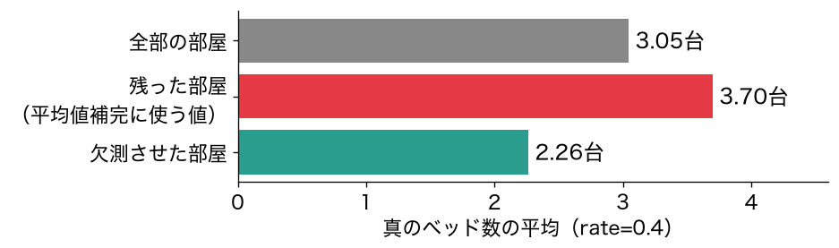

- 欠測させた部屋の真の平均は2.26台。残った部屋は大きめの部屋に偏る

## 残った部屋の平均はずれる

4節 ⑧ 平均がずれる●●●●○

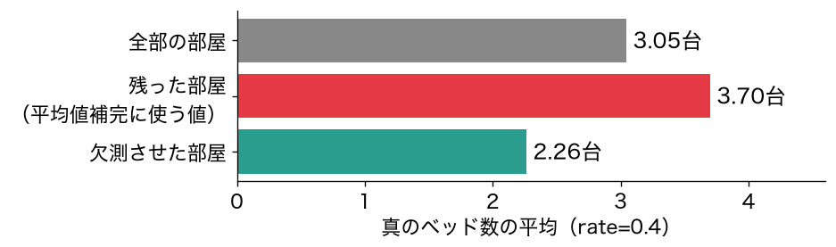

- その大きめの平均で、小さい部屋の欠測を補完することになる
- ランダムな欠測（MAR）のとき、平均そのものがずれる

## 平均値補完しない

4節 ⑧ 平均がずれる●●●●●

- 欠測率が低くても、MAEは1.5台ある
- 平均値補完をせず、ほかの列から予測して補完する

# 5. 実データの欠測を補完する

## 回帰補完を本番の欠測へ

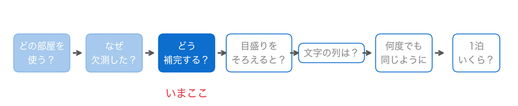

- 練習では、平均値補完するより、定員から回帰補完するほうがずっと当たった
- 本番は、表が訓練とテストの2つ、列が寝室数とベッド数の2本。4行を4回書くことになる

## お手本：回帰補完する関数

5節 ① 関数にする●○○○

```python
def fill_reg(base, df, col):     # 欠測を、定員からの予測で補完する
    ok = base[base[col].notna()]                  # 値の分かる部屋
    m = LinearRegression().fit(ok[['定員']], ok[col])
    df = df.copy()
    df['予測値'] = m.predict(df[['定員']])          # どの部屋も予測
    df[col] = df[col].fillna(df['予測値'])           # 欠測だけ差し替え
    return df

by_reg2 = fill_reg(practice, practice, 'ベッド数')['ベッド数']
print('MAE:', round(np.abs(by_reg2 - truth)[miss].mean(), 2), '台')
```

## 中身は4節と同じ

5節 ① 関数にする●●○○

- 4節のお手本の4行を、`def`の下に並べた
- 列の名前を`col`、表を`df`にして、どの列・どの表にも使えるようにした

## 決める表と補完する表

5節 ① 関数にする●●●○

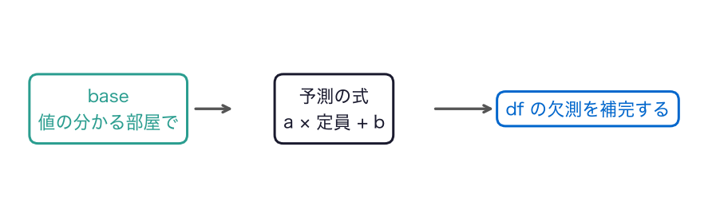

- 予測の式は`base`で作り、欠測を補完するのは`df`
- テストを補完するときも、式は訓練で作りたい。だから表を2つ受け取る

## 4節と同じ0.58台

5節 ① 関数にする●●●●

```
MAE: 0.58 台
```

- 練習用の表で1回呼んで確かめる。4節と同じ数なら、正しくまとまっている

## 訓練の式で両方を補完する

5節 ② 実データを補完する●○○○

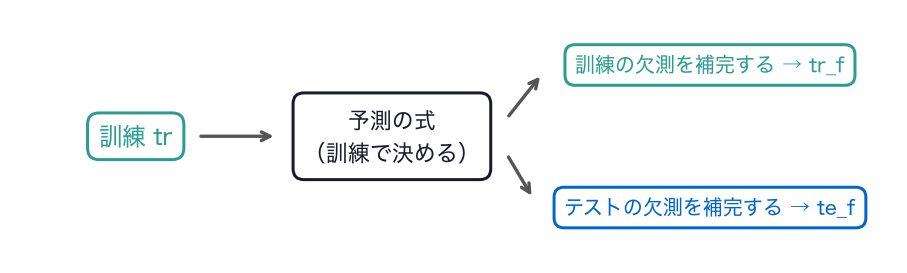

- 予測の式は訓練で1回決め、訓練とテストの両方を補完する

## 変えてみる：訓練とテスト

5節 ② 実データを補完する●●○○

```python
tr_f = fill_reg(tr, tr, '寝室数')
tr_f = fill_reg(tr, tr_f, 'ベッド数')
te_f = fill_reg(tr, te, '寝室数')
te_f = fill_reg(tr, te_f, 'ベッド数')
print(tr_f[cols].isna().sum().sum(), te_f[cols].isna().sum().sum())

model = LinearRegression().fit(tr_f[cols], tr_f['料金'])
print(mae(te_f['料金'], model.predict(te_f[cols])), '円')
```

## テストも訓練の式で補完する

5節 ② 実データを補完する●●●○

```python
te_f = fill_reg(tr, te, '寝室数')
```

- 最初の引数は、4行とも訓練`tr`
- テストは、まだ見ていない部屋の代わりだから

## MAEは8,907円

5節 ② 実データを補完する●●●●

```
0 0
8907 円
```

- 欠測は0件になり、式が作れた。基準の10,860円から約2千円縮んだ
- `.sum().sum()`は、列ごとの数をさらに足して1つの数にする

## 変えてみる：平均値補完すると

5節 ③ 平均と比べる●○○

```python
tr_m = tr.copy()
te_m = te.copy()
for col in ['寝室数', 'ベッド数']:
    tr_m[col] = tr[col].fillna(tr[col].mean())    # 訓練の平均で補完
    te_m[col] = te[col].fillna(tr[col].mean())
model_m = LinearRegression().fit(tr_m[cols], tr_m['料金'])
pred_f = model.predict(te_f[cols])
pred_m = model_m.predict(te_m[cols])
print('回帰補完', mae(te['料金'], pred_f))
print('平均値補完', mae(te['料金'], pred_m))
```

## おさらい：for文

5節 ③ 平均と比べる●●○

```python
for col in ['寝室数', 'ベッド数']:
    tr_m[col] = tr[col].fillna(tr[col].mean())    # 訓練の平均で補完
```

- 並びの中身を1つずつ名前（`col`）に入れながら、字下げした行を繰り返す

## 全体の差は4円

5節 ③ 平均と比べる●●●

```
回帰補完 8907
平均値補完 8911
```

- テストの全部の部屋では、回帰補完8,907円、平均値補完8,911円

## 平均でいいのか？

5節 ④ 欠測した部屋で比べる●○○○○

- 全部の部屋では、4円しか違わない
- それなら、平均値補完してもよいのだろうか。欠測した部屋だけで確かめる

## 変えてみる：欠測した部屋だけ

5節 ④ 欠測した部屋で比べる●●○○○

```python
had = te['寝室数'].isna() | te['ベッド数'].isna()   # 欠測のあった部屋
print(had.sum(), '件')
print('回帰補完', mae(te['料金'][had], pred_f[had]),
      ' 平均', mae(te['料金'][had], pred_m[had]))
```

- `|`は「または」。どちらかが欠測していた部屋がTrue

## 欠測した部屋は1割足らず

5節 ④ 欠測した部屋で比べる●●●○○

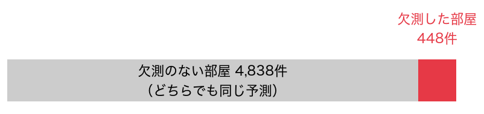

- 残りの9割は補完する必要がなく、どちらでも同じ予測。差が薄まる

## 欠測した部屋では300円

5節 ④ 欠測した部屋で比べる●●●●○

```
448 件
回帰補完 7759  平均 8060
```

- 欠測のあった448件では、回帰補完7,759円、平均値補完8,060円

## 差は補完した部屋に出る

5節 ④ 欠測した部屋で比べる●●●●●

- 補完の方法の差は、補完した部屋に出る。欠測が増えるほど大きくなる
- 全体の点数だけで「平均でも同じ」と判断しない

## やってみよう：5節

5節 ⑤ 確かめる●

- 5節のお手本と「変えてみる」のセルを実行する
- 全体のMAEがほぼ同じでも平均値補完してよいか、ノートの問いの欄に書く

動画の人は、ここで一時停止。

# 6. 目盛りをそろえる

## 列の目盛りがばらばら

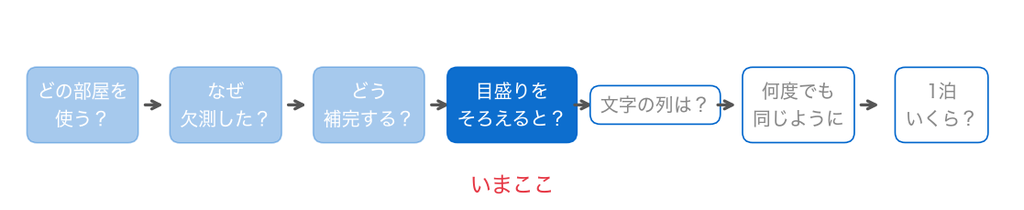

- 欠測が補完できて、料金の式ができた
- 8本の列は、日数・件数・部屋の数と、単位も目盛りもばらばら

## お手本：ばらつきを見る

6節 ① 目盛りを見る●○○

```python
X_tr = tr_f[cols]
X_te = te_f[cols]
print(X_tr.std().round(1))
```

- 役割：訓練の8本の列の、標準偏差を並べる

## 標準偏差を式で

6節 ① 目盛りを見る●●○

$$s = \sqrt{\frac{1}{n-1}\sum_{i=1}^{n} (x_i - \bar{x})^2}$$

- 平均$\bar{x}$からの差（偏差）を二乗して平均し、平方根で元の単位に戻す
- 値が平均からどれくらい散らばっているかの目安

## 92日と0.4室

6節 ① 目盛りを見る●●●

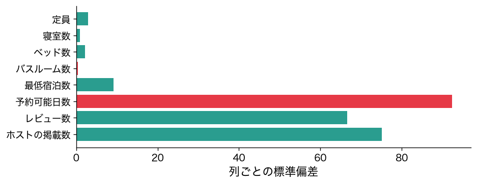

- 予約可能日数は92日も散らばるのに、バスルーム数は0.4室しか散らばらない

## 標準化を式で

6節 ② 標準化●○○○○○○○○

$$z_{ij} = \frac{x_{ij} - \bar{x}_j}{s_j}$$

- $j$番目の列から平均$\bar{x}_j$を引き、標準偏差$s_j$で割る
- 値は「平均から標準偏差いくつぶん離れているか」になる

## 標準化を表で見る

6節 ② 標準化●●○○○○○○○

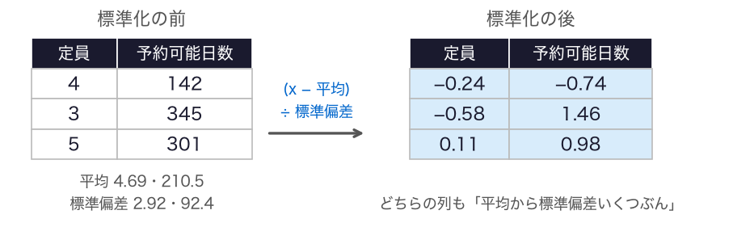

- 訓練の先頭3部屋。定員も予約可能日数も、同じ目盛りになる

## お手本：標準化の関数

6節 ② 標準化●●●○○○○○○

```python
def standardize(X, mean, std):
    return (X - mean) / std

mean_tr = X_tr.mean()            # 列ごとの平均（訓練だけ）
std_tr = X_tr.std()              # 列ごとの標準偏差（訓練だけ）
Z_tr = standardize(X_tr, mean_tr, std_tr)
print(Z_tr.mean().round(2))      # どの列も平均0になったか
print(Z_tr.std().round(2))       # どの列も標準偏差1になったか
```

## 平均は0に

6節 ② 標準化●●●●○○○○○

```
定員         0.0
寝室数        0.0
ベッド数      -0.0
バスルーム数    -0.0
最低宿泊数      0.0
予約可能日数     0.0
レビュー数     -0.0
ホストの掲載数    0.0
dtype: float64
```

- 1つ目の`print`。どの列も平均0にそろった（`-0.0`は0と同じ）

## 標準偏差は1に

6節 ② 標準化●●●●●○○○○

```
定員         1.0
寝室数        1.0
ベッド数       1.0
バスルーム数     1.0
最低宿泊数      1.0
予約可能日数     1.0
レビュー数      1.0
ホストの掲載数    1.0
dtype: float64
```

- 2つ目の`print`。どの列も標準偏差1にそろった
- 平均と標準偏差は、訓練データだけで決めた

## TODO③：テストも標準化

6節 ② 標準化●●●●●●○○○

```python
# TODO: Z_te を作り、列ごとの平均を表示する
# ヒント: Z_te = standardize(X_te, mean_tr, std_tr)
#         上のお手本と同じく .mean().round(2) で表示する
...
```

- テストも、訓練の平均と標準偏差で標準化する

## やってみよう：6節とTODO③

6節 ② 標準化●●●●●●●○○

- 6節のお手本のセルを実行する
- TODO③：テストを標準化して、列ごとの平均を表示する

動画の人は、ここで一時停止。

## 答え合わせ：TODO③

6節 ② 標準化●●●●●●●●○

```
定員         0.03
寝室数        0.01
ベッド数       0.02
バスルーム数    -0.01
最低宿泊数     -0.01
予約可能日数    -0.02
レビュー数     -0.01
ホストの掲載数   -0.03
```

- 0に近いが、ぴったり0ではない

## ぴったり0にならない

6節 ② 標準化●●●●●●●●●

- テストの平均ではなく、訓練の平均を引いたから
- ぴったり0にならないことが、訓練の物差しを使った証拠

## 変えてみる：式を作り直す

6節 ③ 予測と係数●○○○○○

```python
model_z = LinearRegression().fit(Z_tr, tr_f['料金'])
pred_z = model_z.predict(standardize(X_te, mean_tr, std_tr))
print(mae(te_f['料金'], pred_z), '円')
coef = pd.DataFrame({'そのまま': model.coef_,
                     '標準化後': model_z.coef_}, index=cols)
print(coef.round(0))
```

- 標準化した訓練で式を作り、MAEと係数を並べる

## MAEは1円も変わらない

6節 ③ 予測と係数●●○○○○

```
8907 円
```

- 標準化する前と同じ8,907円

## 係数が目盛りを吸収する

6節 ③ 予測と係数●●●○○○

$$\hat{y} = b_0 + \sum_j b_j x_j = b'_0 + \sum_j b'_j z_j, \qquad b'_j = b_j\,s_j$$

- $z_j=(x_j-\bar{x}_j)/s_j$を入れると、係数が$s_j$倍になるだけ。予測は同じ
- 例：バスルーム数は$3537 \times 0.40 \approx 1415$円（丸める前の標準偏差では1,414円）

## 変わるのは係数

6節 ③ 予測と係数●●●●○○

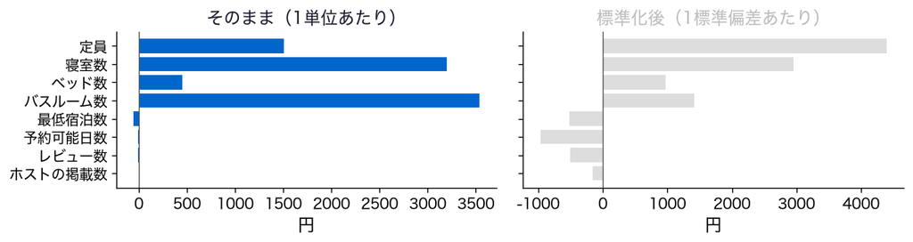

- そのままでは、バスルーム数1室で3,537円、定員1人で1,507円
- バスルーム数のほうが効くように見える。でも、0.4室しか散らばらない列

## 同じ目盛りで並ぶ

6節 ③ 予測と係数●●●●●○

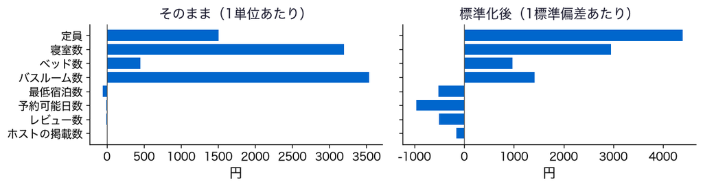

- 標準化後は「標準偏差1つぶん増えたら何円」。定員4,395円がいちばん
- バスルーム数は1,414円。列どうしを同じ物差しで比べられる

## 比べたいなら目盛りをそろえる

6節 ③ 予測と係数●●●●●●

- 予測には効かなくても、列どうしを比べたいときは目盛りをそろえる
- その物差し（平均と標準偏差）も、訓練データだけで決める

# 7. 文字の列を式に入れる

## 残る手がかりは地区

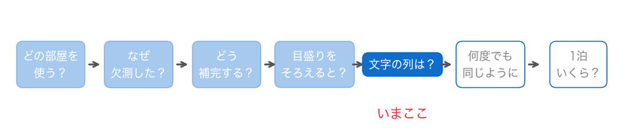

- 数の列は、補完し、目盛りもそろえられるようになった
- 残る手がかりの地区は文字の列。このままでは式に入らない

## お手本：地区ごとの料金

7節 ① 地区で違うか●○

```python
by_area = tr.groupby('地区')['料金'].agg(['median', 'count'])
by_area = by_area[by_area['count'] >= 30].sort_values('median')
print(len(by_area), '地区')
print(by_area.head(3))
print(by_area.tail(3))
```

- `sort_values('median')`は中央値の小さい順、`head(3)`・`tail(3)`は先頭・末尾の3行

## 地区で2倍違う

7節 ① 地区で違うか●●

```
25 地区
              median  count
地区
Ota Ku       14591.0    986
Arakawa Ku   15406.0    111
Itabashi Ku  16114.0    461
             median  count
地区
Minato Ku   27985.0    960
Chiyoda Ku  28790.0    119
Meguro Ku   29355.0     78
```

- 大田区（`Ota Ku`）14,591円、目黒区（`Meguro Ku`）29,355円。地区は使いたい手がかり

## 番号を振ると

7節 ② 番号を振る●○○○○○○○

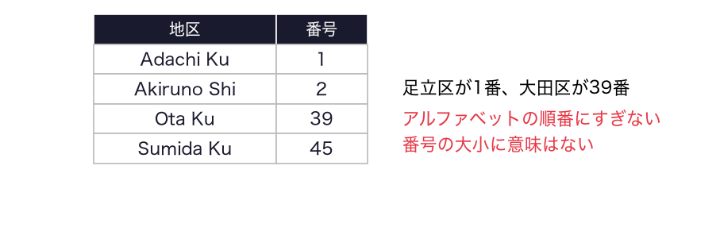

- いちばん手っ取り早いのは、地区に1番から番号を振って、数として式に入れること

## 変えてみる：番号を振る

7節 ② 番号を振る●●○○○○○○

```python
order = sorted(tr['地区'].unique())          # アルファベット順
code = {}
for i in range(len(order)):
    code[order[i]] = i + 1                   # 1番から番号を振る

Xc_tr = X_tr.assign(地区番号=tr['地区'].map(code))
Xc_te = X_te.assign(地区番号=te['地区'].map(code))
m_c = LinearRegression().fit(Xc_tr, tr_f['料金'])
print(mae(te_f['料金'], m_c.predict(Xc_te)), '円')
print('番号1つあたり', round(m_c.coef_[-1]), '円')
```

## 辞書に番号を入れる

7節 ② 番号を振る●●●○○○○○

```python
code = {}
for i in range(len(order)):
    code[order[i]] = i + 1                   # 1番から番号を振る
```

- `sorted`はアルファベット順に並べる。`code[名前] = 番号`で、辞書に組を足していく
- `map(code)`で地区の名前を番号に置き換え、`assign`で列を足す

## MAEは8,819円

7節 ② 番号を振る●●●●○○○○

```
8819 円
番号1つあたり 115 円
```

- 番号なし（8,907円）より少し縮んだ。番号が1つ増えると115円上がる、という式

## TODO④：並べ方を変える

7節 ② 番号を振る●●●●●○○○

```python
# TODO: 件数の多い順に番号を振り直し、MAE と係数を表示する
# ヒント: order = list(tr['地区'].value_counts().index) にして、
#         上のセルの残りをそのまま写す
...
```

- 同じ地区の情報で、振り方だけを変える

## やってみよう：7節前半とTODO④

7節 ② 番号を振る●●●●●●○○

- 7節のお手本と「変えてみる」のセルを実行する
- TODO④：件数の多い順に番号を振り直し、係数を比べる

動画の人は、ここで一時停止。

## 答え合わせ：TODO④

7節 ② 番号を振る●●●●●●●○

```
8851 円
番号1つあたり -211 円
```

- MAEは8,851円、番号1つあたりは−211円。アルファベット順では+115円だった

## 番号の大小に意味はない

7節 ② 番号を振る●●●●●●●●

- 振り方を変えただけで、係数の向きが逆になった
- 番号の順番には意味がないのに、式は1本の傾きを当てはめてしまう
- 区分を表す文字の列に、番号を振って数として入れてはいけない

## 地区ごとに列を作る

7節 ③ ダミー変数●○○○

$$d_{ik} = \begin{cases} 1 & (\text{部屋}\,i\,\text{が地区}\,k) \\ 0 & (\text{それ以外}) \end{cases}$$

- 地区ごとに1本ずつ列を作り、その地区なら1、そうでなければ0
- この0と1の列を、ダミー変数（dummy variable）と呼ぶ

## ダミー変数を表で見る

7節 ③ ダミー変数●●○○

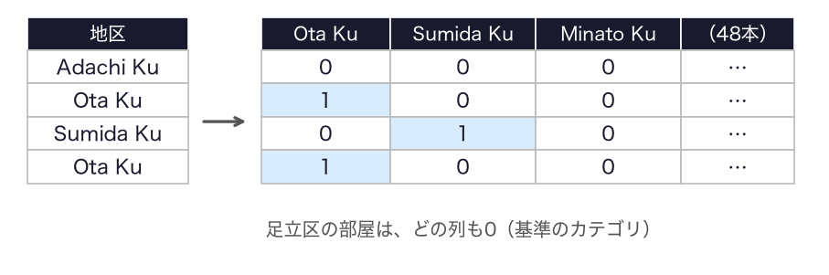

- 足立区（アルファベット順で最初）の列は作らない。どの列も0の部屋が足立区（基準のカテゴリ）

## お手本：ダミー変数にする

7節 ③ ダミー変数●●●○

```python
D_tr = pd.get_dummies(tr['地区'], drop_first=True, dtype=int)
print(tr['地区'].nunique(), '地区')
print(D_tr.shape)
print(list(D_tr.columns[:4]))
```

- `pd.get_dummies`は、文字の列からダミー変数の表を作る。`drop_first=True`で最初の地区の列を作らない

## 49地区から48本

7節 ③ ダミー変数●●●●

```
49 地区
(21144, 48)
['Akiruno Shi', 'Akishima Shi', 'Arakawa Ku', 'Bunkyo Ku']
```

- 基準の足立区を除いた48本。列の名前は地区の名前そのもの

## テストは42地区しかない

7節 ④ 列をそろえる●○○○○

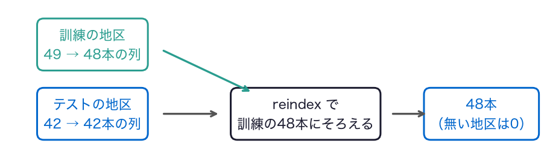

- そのまま作ると列が42本になり、訓練の48本とずれる。訓練の列にそろえる

## 変えてみる：列をそろえる

7節 ④ 列をそろえる●●○○○

```python
print(te['地区'].nunique(), '地区')      # テストの地区の数
D_te = pd.get_dummies(te['地区'], dtype=int)
# 訓練の列にそろえる
D_te = D_te.reindex(columns=D_tr.columns, fill_value=0)
A_tr = pd.concat([X_tr, D_tr], axis=1)
A_te = pd.concat([X_te, D_te], axis=1)
m_d = LinearRegression().fit(A_tr, tr_f['料金'])
print(A_tr.shape, A_te.shape)
print(mae(te_f['料金'], m_d.predict(A_te)), '円')
```

## reindexとconcat

7節 ④ 列をそろえる●●●○○

```python
# 訓練の列にそろえる
D_te = D_te.reindex(columns=D_tr.columns, fill_value=0)
A_tr = pd.concat([X_tr, D_tr], axis=1)
```

- `reindex`：列を訓練と同じ名前・順番に並べ直す。無い地区の列は0で作る
- `pd.concat([表1, 表2], axis=1)`：2つの表を横につなぐ

## MAEは8,215円

7節 ④ 列をそろえる●●●●○

```
42 地区
(21144, 56) (5286, 56)
8215 円
```

- 56本（数の列8＋地区48）にそろい、MAEは8,907円から8,215円へ692円縮んだ

## 列も訓練で決める

7節 ④ 列をそろえる●●●●●

- ダミー変数の列も、訓練で決めた列にそろえる
- 補完や標準化と同じく、「訓練で決める」の1つ

## やってみよう：7節後半

7節 ⑤ 確かめる●

- 7節の残りのセルを実行し、地区を入れたMAEを確かめる

動画の人は、ここで一時停止。

# 8. 同じ整え方を何度でも

## 何度も同じ整え方を

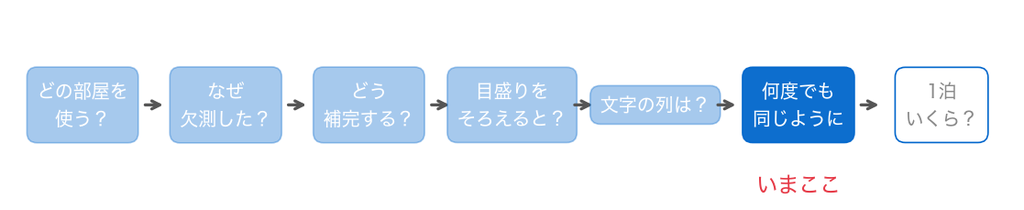

- 整え方がそろった。文字から戻す・訓練の式で予測して補完する・地区をダミー変数にする
- 訓練にもテストにも、あなたの部屋にも、同じように当てる必要がある

## 書き写すとずれる

8節 ① prepにまとめる●○○○○○○○

- 5節と7節では、訓練とテストに同じ行を何度も書いた
- 毎回同じ行を書き写すと、どこかでずれる。1つの関数にまとめる

## prepの中を通る順

8節 ① prepにまとめる●●○○○○○○

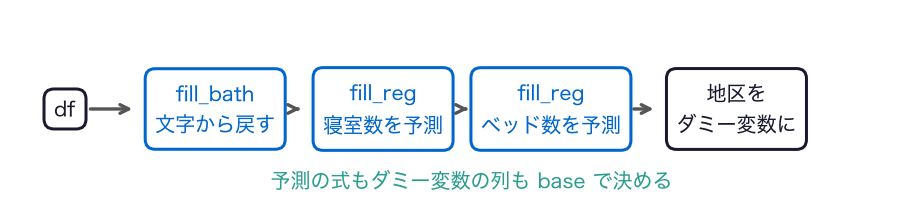

- 表`df`が、4つの処理を順に通り、手がかりの表になって出てくる

## お手本：prepにまとめる

8節 ① prepにまとめる●●●○○○○○

```python
def prep(base, df):           # 決めるのは base、整えるのは df
    df = fill_bath(df)
    df = fill_reg(base, df, '寝室数')
    df = fill_reg(base, df, 'ベッド数')
    area_cols = pd.get_dummies(base['地区'], drop_first=True).columns
    area = pd.get_dummies(df['地区'], dtype=int)
    area = area.reindex(columns=area_cols, fill_value=0)
    return pd.concat([df[cols], area], axis=1)

model = LinearRegression().fit(prep(tr, tr), tr['料金'])
err = mae(te['料金'], model.predict(prep(tr, te)))
print('訓練で決めた:', err, '円')
```

## 関数の中で関数を呼ぶ

8節 ① prepにまとめる●●●●○○○○

```python
    df = fill_bath(df)
    df = fill_reg(base, df, '寝室数')
```

- 3節の`fill_bath`と、5節の`fill_reg`を呼んでいる
- 小さな関数を組み合わせて、大きな処理を作る

## どの関数も表はdf

8節 ① prepにまとめる●●●●●○○○

- `fill_bath`・`fill_reg`・`prep`は、どれも受け取った表を`df`と呼ぶ
- 名前は関数ごとに別なので、同じ`df`でも混ざらない（4節）
- 1節で絞った外の`df`（全データ）とも、別のもの

## 列もbaseで決める

8節 ① prepにまとめる●●●●●●○○

```python
    area_cols = pd.get_dummies(base['地区'], drop_first=True).columns
    area = area.reindex(columns=area_cols, fill_value=0)
```

- ダミー変数の列（`area_cols`）も`base`の地区から決め、`df`の列をそろえる
- `base`に訓練を渡せば、どの表も訓練で決めた整え方で整う

## 決める表と整える表

8節 ① prepにまとめる●●●●●●●○

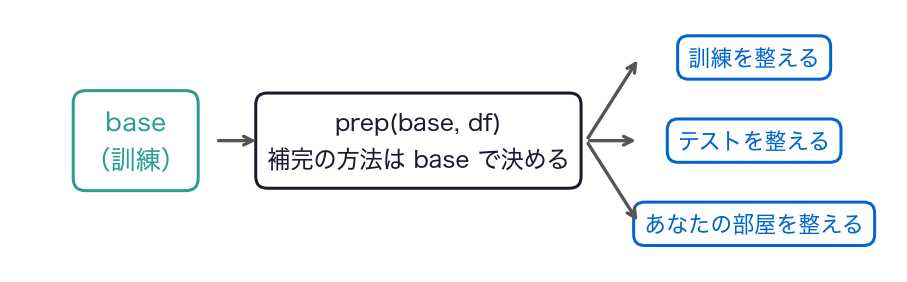

- 補完の方法とダミー変数の列を決める表`base`と、整える表`df`を分けて受け取る

## 7節と同じ8,215円

8節 ① prepにまとめる●●●●●●●●

```
訓練で決めた: 8215 円
```

- 3節・5節・7節で書いた整え方が、`prep`の呼び出し1つにまとまった

## 変えてみる：全データで決める

8節 ② 順番を守る●○○○

```python
model_l = LinearRegression().fit(prep(df, tr), tr['料金'])
err_l = mae(te['料金'], model_l.predict(prep(df, te)))
print('全データで決めた:', err_l, '円')
```

- 最初の引数を、訓練`tr`から全データ`df`に変えるだけ
- 外の`df`は、`prep`の中では`base`という名前で受け取られる

## 差は出なかった

8節 ② 順番を守る●●○○

```
全データで決めた: 8215 円
```

- 訓練だけで決めたとき（8,215円）と同じ
- 2万件以上あると、テストを混ぜても予測の式も地区の顔ぶれも、ほとんど変わらない

## それでも訓練だけで決める

8節 ② 順番を守る●●●○

- テストの情報が、前処理を通して式に漏れる（第2回のリーク）
- データが少ないとき、テストの部屋だけ傾向が違うときは、差が大きく出る

## 関数の形が順番を守る

8節 ② 順番を守る●●●●

- 差が出るかを確かめてから守るのではなく、いつも訓練だけで決める
- 「決める表」と「整える表」を分けた関数にしておくと、間違えにくい

## やってみよう：8節

8節 ③ 確かめる●

- 8節のお手本と「変えてみる」のセルを実行する

動画の人は、ここで一時停止。

# 9. 1泊いくら？

## いよいよ値付け

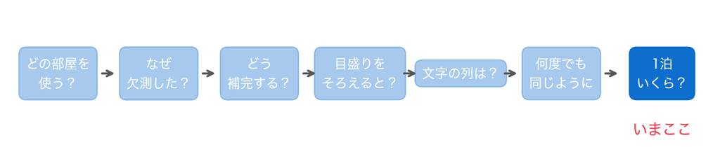

- 整え方を`prep`1つにまとめた
- あなたの部屋に、値段を付ける

## 新しい部屋も同じ道を通る

9節 ① あなたの部屋●○○○○○

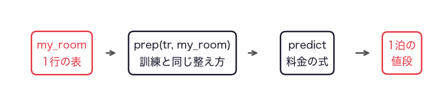

- あなたの部屋も、訓練で決めた整え方を通し、同じ式で予測する

## お手本：あなたの部屋

9節 ① あなたの部屋●●○○○○

```python
my_room = pd.DataFrame({'地区': ['Sumida Ku'],
                        '定員': [4], '寝室数': [2],
                        'ベッド数': [2], 'バスルーム数': [1],
                        'バスルームの表記': ['1 bath'],
                        '最低宿泊数': [2], '予約可能日数': [200],
                        'レビュー数': [0], 'ホストの掲載数': [1]})
price = model.predict(prep(tr, my_room))[0]
print(round(price), '円')
```

- 墨田区（`Sumida Ku`）にある、定員4人・寝室2・ベッド2の貸切の部屋とする

## 24,251円

9節 ① あなたの部屋●●●○○○

```
24251 円
```

- 予測は1つしかないが、並びで返ってくる。`[0]`で1つ目を取り出す
- 地区のダミー変数も、`prep`が訓練の48本の列にそろえる

## TODO⑤：自分の部屋

9節 ① あなたの部屋●●●●○○

```python
# TODO: my_room の条件を変えた部屋を作り、prep と model で値付けする
# ヒント: room2 = my_room.assign(地区='Minato Ku')
#         のように、assign で列の値を変えた表を作れる
...
```

- 寝室数が分からない部屋なら、`np.nan`を入れてもよい。`prep`が補完する

## やってみよう：9節とTODO⑤

9節 ① あなたの部屋●●●●●○

- 9節のお手本のセルを実行する
- TODO⑤：地区や定員を自分で決めて、値付けする

動画の人は、ここで一時停止。

## 答え合わせ：TODO⑤

9節 ① あなたの部屋●●●●●●

```
Minato Ku 35613 円
Ota Ku 19442 円
定員2・寝室1・ベッド1: 16990 円
寝室数が空欄        : 21833 円
```

- 同じ部屋でも港区なら約3万6千円、大田区なら約1万9千円。地区で大きく変わる

## 答え：およそ2万4千円

9節 ② 答え●○

墨田区のあなたの部屋は、1泊およそ2万4千円（24,251円）。

- 相場に入れたのは、1泊10万円以下の貸切の部屋

## MAEは8,200円ほど

9節 ② 答え●●

- まだ見ていない部屋でのMAEは、およそ8,200円
- 2万4千円と言っても、それくらいは外れうる

## まだ言えないこと①：物差し

9節 ③ まだ言えないこと●○○

- MAEだけで測ってよいのか
- 大きな誤差を重く見る物差しもある

## まだ言えないこと②：少ない地区

9節 ③ まだ言えないこと●●○

```python
print(tr['地区'].value_counts().tail(3))
```

```
地区
Koganei Shi            2
Musashimurayama Shi    1
Inagi Shi              1
```

- 稲城市・武蔵村山市のように、訓練に1件しかない地区もある
- そのダミー変数の係数は、わずかな件数の料金だけで決まり、当てにならない

## まだ言えないこと③：揺れ

9節 ③ まだ言えないこと●●●

- 回帰補完した値は1本の線に乗る。真の値より揃いすぎている
- これは発展で扱う

# まとめ

## 今日の道筋を振り返る

⑤ 振り返る●○○○○

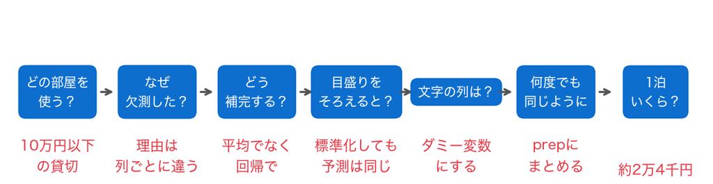

- 7つの小さな問いに答えて、あなたの部屋の値段にたどり着いた

## 今日の歩み

⑤ 振り返る●●○○○

外す行 → 欠測の理由 → 補完の評価 → 目盛り → 文字の列 → 同じ整え方 → 値付け

## 今日持ち帰る1文

⑤ 振り返る●●●○○

欠測値は、1つの値で補完しない。欠測した理由を確かめ、ほかの列から予測して補完する。整え方は訓練データだけで決め、関数にして、新しい部屋にも同じように当てる。

## 今日の要点①：欠測

⑤ 振り返る●●●●○

- 外す行は、目標から理由を説明でき、線を書き残せるときに外す
- 欠測値は、理由を先に確かめる。値が存在しない欠測は補完しない。別の列から戻せるなら戻す
- 平均値補完すると、補完値の誤差が大きく、列どうしの関係が弱まる。平均そのものもずれる
- 答えの分かる欠測を作れば、補完の方法を評価できる

## 今日の要点②：整え方

⑤ 振り返る●●●●●

- 標準化で目盛りをそろえる。線形回帰の予測は同じで、係数を比べやすくなる
- 区分の文字の列に番号を振らない。ダミー変数にして、訓練の列にそろえる
- Python：`def`で関数を作る。既定値つきの引数で切り替え、小さな関数を組み合わせる

## 課題の出し方

⑥ このあと●○○○

- ノートの最後の「課題（提出）」に取り組む
- 応用②の答えと応用③の文章を、LACSに入力して提出（＝出席。期限なし）
- AIを使ってもよい。何を聞いて、どう直したかを1行書く

## 次回予告：住宅の査定

⑥ このあと●●○○

- 場面は、住宅の査定
- MAE以外の物差しで式を測り、式の係数を読む

## 次回の問い

⑥ このあと●●●○

「この家は、なぜこの値段なのか」を説明する式を、どの物差しで選び、どう読むか？

## このあと：課題へ

⑥ このあと●●●●

ノートの「課題（提出）」へ。寝室数を欠測させて、平均値補完のときと回帰補完したときを評価します。

# ここから先は解答

## 課題のあとで見る

課題（提出）に取り組んでから見てください。動画の人は、ここで一時停止。

## 応用①：寝室数で評価

```python
full_bed = tr[tr['寝室数'].notna()]
practice = make_missing(full_bed, '寝室数', 0.2)
miss = practice['寝室数'].isna()
truth_bed = full_bed['寝室数']
by_mean = practice['寝室数'].fillna(practice['寝室数'].mean())
by_reg = fill_reg(practice, practice, '寝室数')['寝室数']
print('平均 MAE', round(np.abs(by_mean - truth_bed)[miss].mean(), 2))
print('回帰 MAE', round(np.abs(by_reg - truth_bed)[miss].mean(), 2))
print('補完に使った平均', round(practice['寝室数'].mean(), 2))
print('相関 真', round(full_bed['定員'].corr(truth_bed), 3),
      ' 平均', round(full_bed['定員'].corr(by_mean), 3))
```

- 4節のセルの`full`を`full_bed`に、`'ベッド数'`を`'寝室数'`に変える

## 平均値0.67室・回帰0.31室

```
平均 MAE 0.67
回帰 MAE 0.31
補完に使った平均 1.62
相関 真 0.792  平均 0.716
```

- 寝室数でも、平均値補完のMAEは回帰補完の2倍以上

## 応用②：答えは0.67

- 平均値補完のときの、欠測させた部屋でのMAEは0.67室
- 回帰補完なら0.31室

## 応用③：模範例

寝室数を平均（約1.6室）で補完すると、欠測させた部屋でのMAEは0.67室で、回帰補完したとき（0.31室）の2倍以上になりました。寝室数は小さい部屋ほど欠測しやすいので、残った部屋の平均は大きめにずれ、ワンルームのような部屋にも1.6室が入ります。欠測した寝室数は、まず欠測した理由を確かめ、補完するなら定員のような関係の強い列から予測します。

## 書き方の型

- 1文目：自分の出力の数値で、平均値補完と回帰補完のMAEを比べる（0.67室と0.31室）
- 2文目：平均がよくない理由を、欠測のメカニズムから説明する
- 3文目：ホストへの勧め（理由を確かめる、ほかの列から予測する）

# 発展（任意）

## 回帰補完は揃いすぎている

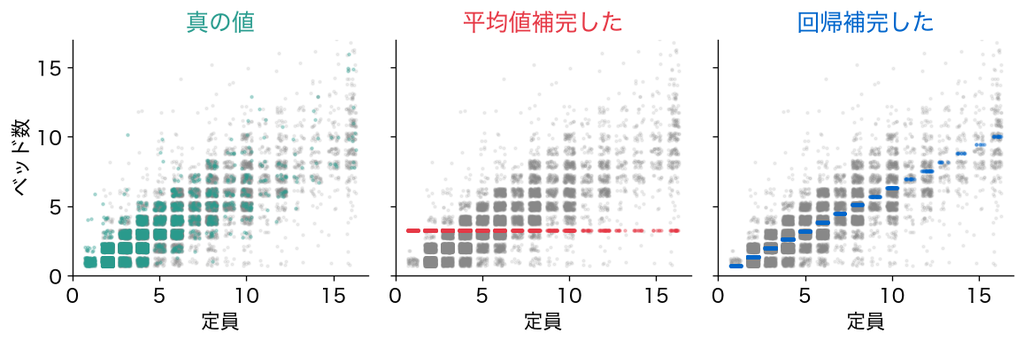

- 回帰補完した値（青）は、1本の線にぴったり乗る
- 真のベッド数は、同じ定員でも部屋ごとに散らばっている

## ランダムな誤差を足して補完する

- 予測値に、「真の値と予測の誤差」と同じくらいのランダムな誤差を足す
- ランダムな誤差の大きさは、予測の誤差の標準偏差で決める

## ランダムな誤差を式で

$$\tilde{x}_i = \hat{x}_i + \varepsilon_i, \qquad \varepsilon_i \sim N(0,\, s^2)$$

- $\hat{x}_i$は予測値、$\varepsilon_i$は平均0・標準偏差$s$の正規分布に従う乱数
- $s$は、値の分かる部屋での予測の誤差$x_k - \hat{x}_k$の標準偏差
- この補完を、確率的回帰補完（stochastic regression imputation）と呼ぶ

## お手本：ランダムな誤差を足す

```python
truth = full['ベッド数']
practice = make_missing(full, 'ベッド数', 0.2)
miss = practice['ベッド数'].isna()
ok = practice[practice['ベッド数'].notna()]
m = LinearRegression().fit(ok[['定員']], ok['ベッド数'])
# 予測の誤差の散らばり（標準偏差）
s = (ok['ベッド数'] - m.predict(ok[['定員']])).std()
print('予測の誤差の標準偏差:', round(s, 2))

by_reg = fill_reg(practice, practice, 'ベッド数')['ベッド数']
rng = np.random.default_rng(1)
by_noise = by_reg.copy()
by_noise[miss] = by_reg[miss] + rng.normal(0, s, miss.sum())
for name, val in [('真の値', truth), ('回帰補完', by_reg),
                  ('確率的回帰補完', by_noise)]:
    print(name, ' 相関', round(full['定員'].corr(val), 3),
          ' 標準偏差', round(val.std(), 2))
print('0より小さい値:', (by_noise[miss] < 0).sum(), '件')
```

## 正規分布の乱数

```python
by_noise[miss] = by_reg[miss] + rng.normal(0, s, miss.sum())
```

- `rng.normal(0, s, 個数)`：平均0・標準偏差`s`の正規分布に従う乱数を出す
- 欠測させた部屋の数だけ出して、予測値に足す

## 今度は散らばりすぎる

```
予測の誤差の標準偏差: 1.21
真の値  相関 0.848  標準偏差 2.16
回帰補完  相関 0.863  標準偏差 2.11
確率的回帰補完  相関 0.833  標準偏差 2.19
0より小さい値: 342 件
```

- 回帰補完だけだと、相関は強く（0.863）、標準偏差は小さく（2.11）出る。揃いすぎ
- ランダムな誤差を足すと、相関0.833・標準偏差2.19。今度は反対側にずれる

## 図で見ると

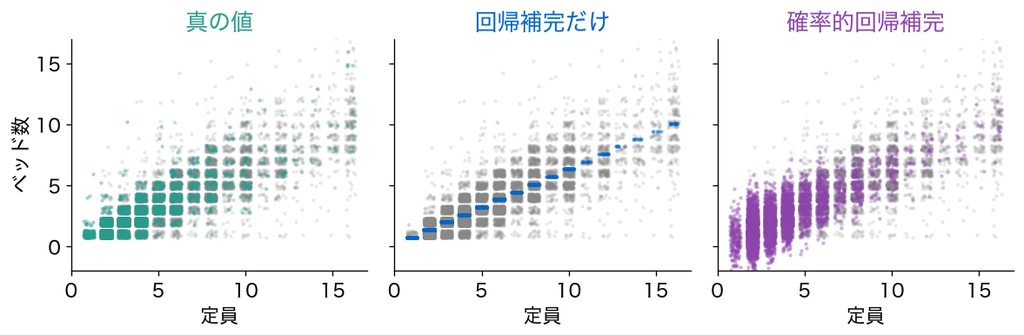

```
0より小さい値: 342 件
```

- 紫の点は1本の線ではなくなるが、小さい部屋で散らばりすぎ、0より小さい値も出る

## 誤差の大きさが同じだから

- 真のベッド数は、小さい部屋ではあまり散らばらず、大きい部屋ではよく散らばる
- それなのに、どの部屋にも同じ$s=1.21$のランダムな誤差を足した
- 本格的な方法では、ランダムな誤差の大きさも、部屋に合わせてデータから決める

## 何通りも作る：多重代入

- ランダムな誤差を足す考え方には意味がある。ランダムな誤差は乱数なので、シードを変えれば補完した値も変わる
- シードを変えて何通りも補完し、それぞれで分析して結果をまとめる
- 補完した値の不確かさを、結果の幅として残せる。これを多重代入と呼ぶ

## 多重代入の流れ

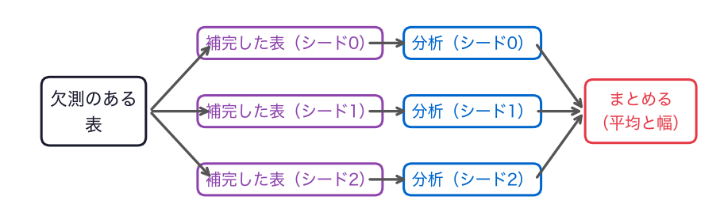

- シードを変えて補完した表それぞれで分析し、結果の平均と幅をまとめる

## 試すなら

- `rate`を0.4に上げて、回帰補完だけ・ランダムな誤差を足したときの相関と標準偏差が、真の値からどちらにずれるかを比べる
- シードを5通りに変えて、補完した値が変わっても相関が変わるかを見る

## おわり

- 今日は、データを整えて、墨田区のあなたの部屋に1泊およそ2万4千円を付けた
- 欠測値は、1つの値で補完しない